# vyasj2 Homework5

## Bi-Weekly Work Summary

- RCS ID: vyasj2
- Project Name: IDEA-Blockchain
- Summary of work for last 2 weeks
  - Used the transactionsv2 data that Chris provided to run some more survival analysis for the bigger goal of creating a table or chart that depicts coin instability vs liquidation rate.
- Summary of github commits
  - dar-vyasj2
  - https://github.rpi.edu/DataINCITE/IDEA-Blockchain/blob/dar-vyasj2/DefiResearch/StudentNotebooks/analysisv2.Rmd
  - All done by me

## Personal Contribution

- The idea was to be able to graph coin instability (i.e., fluctuations in price), against the liquidation rate so come up with some meaningful statistics that would help determine when are the most/least dangerous times to borrow, what kind of borrow parameters are the most/least dangerous, and the circumstances that existed when borrow liquidated.

## Discussion

- Discuss primary findings:
  - I wanted to know the relationship between fluctuation of coin price to rate of liquidation
  - I started by filtering down the dataset to only WETH borrows, since it’s not pegged to anything so there should be a good amount of instability, and because ETH is a very commonly used currency. I then graphed the difference between the price of WETH that the borrow was made at and the price of WETH that the borrow was liquidated at. I thought this would be of value because it would show us how the difference in price between these two values changes over time. My idea was that this might show some sort of pattern between the prices which would give us insight into the variability of the price.
  - I then started to graph Kaplan-Meier Survival Curves of the probability of a WETH loan’s survival over time based on different factors, like the type of borrow rate (stable or variable), and the principal reserve. My goal with this was to see how different categorical variables might affect the survival rate of a loan over time. There are a lot of things to be seen from the principal reserve graph, as there are a lot of different reserves that each give a different probability over time. I then created a multivariate Cox Proportional-Hazards Model that took into account both of these variables, the type of borrow rate and the principal reserve. It has a very large confidence interval at the middle, indicating that there is a very large variability when we use these two factors to describe the data.
  - The next steps would be to find variables that lower this variability as much as possible, and then make the correlation between fluctuation of reserve price and rate or probability of liquidation.

```r
if (!require(readr)) {
  install.packages("readr")
  library(readr)
}
```

```r
if (!require("ggplot2")) {
  install.packages("ggplot2")
  library(ggplot2)
}
if (!require("lubridate")) {
  install.packages("lubridate")
  library(lubridate)
}
if (!require("dplyr")) {
    install.packages("dplyr")
    library(dplyr)
}
if (!require("roll")) {
  install.packages("roll")
  library(roll)
}
if (!require("survival")) {
  install.packages("survival")
  library(survival)
}
if (!require("ggfortify")) {
  install.packages("ggfortify")
  library(ggfortify)
}
if (!require("tidyr")) {
  install.packages("tidyr")
  library(tidyr)
}
if (!require("survminer")) {
  install.packages("survminer")
  library(survminer)
}
if (!require("plotly")) {
  install.packages("plotly")
  library(plotly)
}
df <- read_rds("../../Data/transactionsv2.rds")
df <- df %>%
  dplyr::mutate(date=as_datetime(timestamp))
head(df)
```

```
##       amount borrowRate borrowRateMode   onBehalfOf         pool reserve
## 1      15.00  0.2590658       Variable 1.117217e+48 1.034668e+48    WETH
## 2   41501.63  6.2749368       Variable 8.502518e+47 1.034668e+48     DAI
## 3 7000000.00  2.5896280       Variable 4.635974e+47 1.034668e+48    USDT
## 4   15000.00  8.8025409       Variable 3.735263e+47 1.034668e+48    USDC
## 5    8193.19 48.7470516         Stable 6.896232e+47 1.034668e+48    USDC
## 6   11000.00  3.2250550       Variable 1.089455e+48 1.034668e+48    USDT
##    timestamp         user   type reservePriceETH reservePriceUSD  amountUSD
## 1 1633275840 1.168069e+48 borrow    1.0000000000    3421.8708189   51328.06
## 2 1621340435 8.502518e+47 borrow    0.0002852900       0.9948044   41286.00
## 3 1622477822 4.635974e+47 borrow    0.0003812835       1.0000000 7000000.00
## 4 1619775984 3.735263e+47 borrow    0.0003611000       1.0043389   15065.08
## 5 1615481632 6.896232e+47 borrow    0.0005562201       0.9993909    8188.20
## 6 1626914745 1.089455e+48 borrow    0.0004971100       1.0000000   11000.00
##   collateralAmount collateralReserve liquidator principalAmount
```

[output cut: 41 more lines]

```r
borrows <- df %>%
  dplyr::filter(type=="borrow")

reservePrices <- df %>%
  dplyr::select(reserve,reservePriceUSD,date)

head(reservePrices)
```

```
##   reserve reservePriceUSD                date
## 1    WETH    3421.8708189 2021-10-03 15:44:00
## 2     DAI       0.9948044 2021-05-18 12:20:35
## 3    USDT       1.0000000 2021-05-31 16:17:02
## 4    USDC       1.0043389 2021-04-30 09:46:24
## 5    USDC       0.9993909 2021-03-11 16:53:52
## 6    USDT       1.0000000 2021-07-22 00:45:45
```

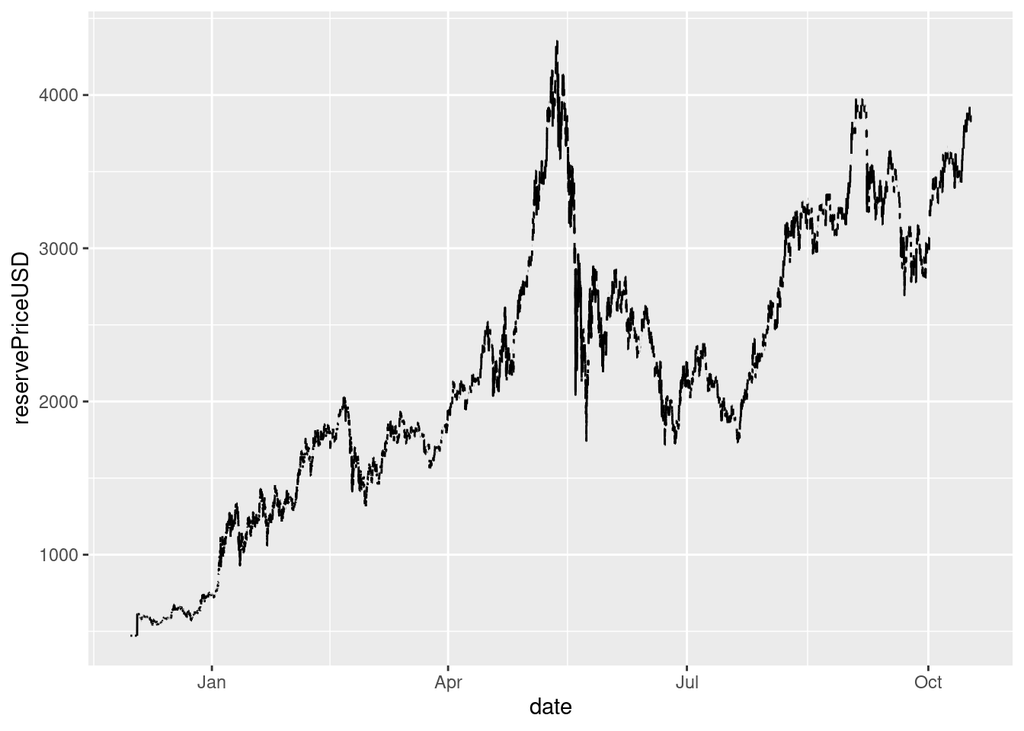

```r
wethPrice <- reservePrices %>%
  dplyr::filter(reserve=="WETH") %>%
  dplyr::mutate(sdPrice=roll::roll_sd(reservePriceUSD,width=21)) %>%
  dplyr::mutate(avgPrice=roll::roll_mean(reservePriceUSD,width=21))

ggplot(wethPrice,aes(x=date,y=reservePriceUSD)) + geom_line()
```

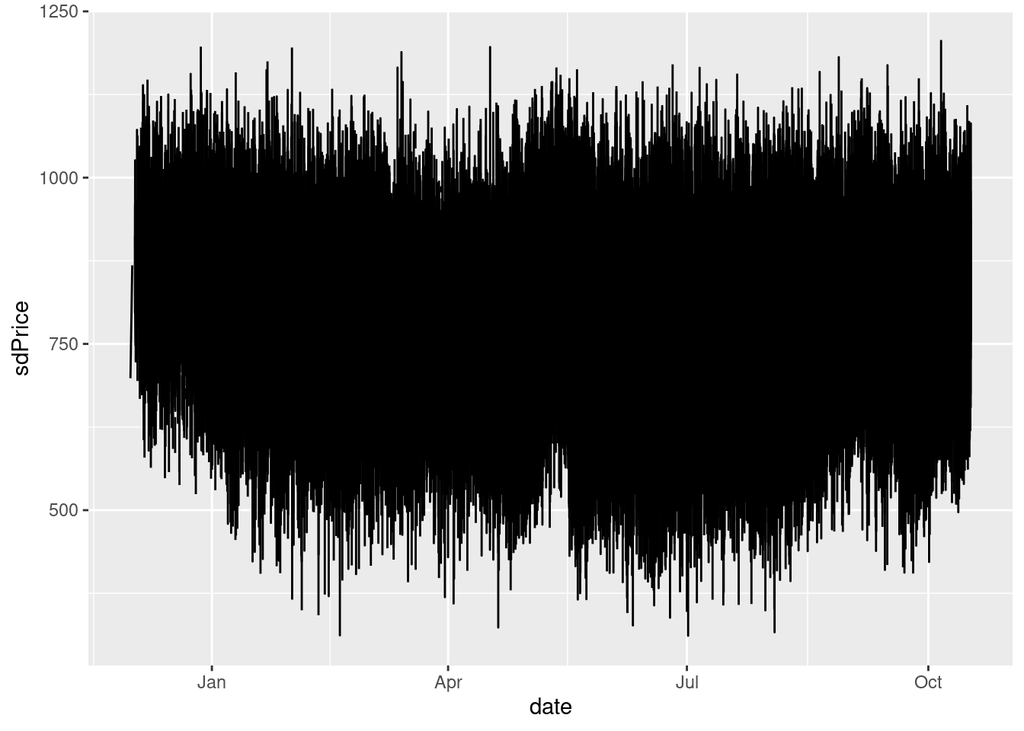

```r
ggplot(wethPrice,aes(x=date,y=sdPrice)) + geom_line()
```

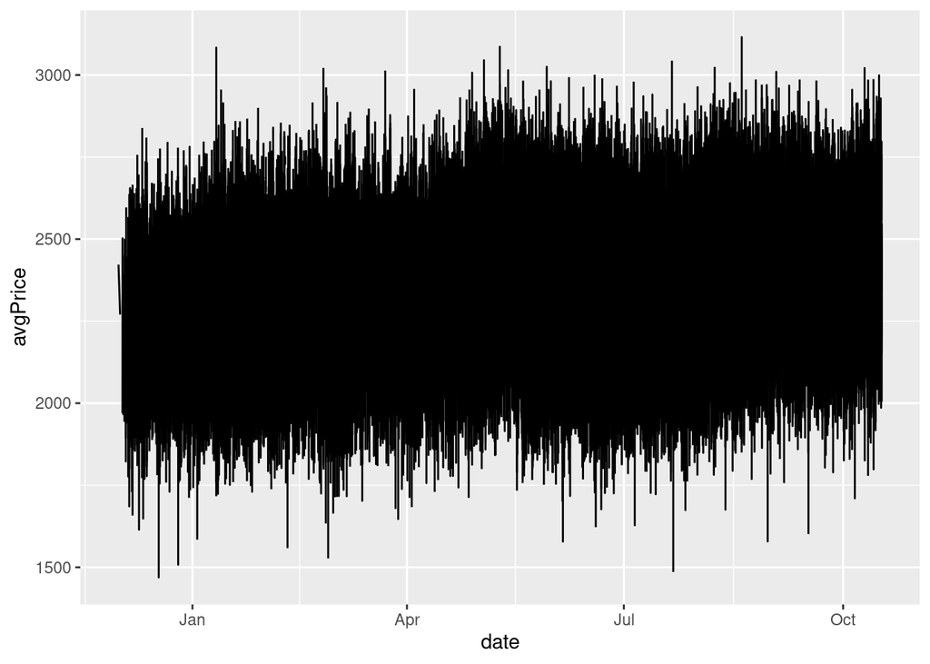

```r
ggplot(wethPrice,aes(x=date,y=avgPrice)) + geom_line()
```

```r
liquidations <- df %>%
  dplyr::filter(type=="liquidation")

wethLiquids <- liquidations %>%
  dplyr::filter(collateralReserve=="WETH") %>%
  dplyr::select(user_alias,date,reservePriceUSDPrincipal,timestamp,principalReserve,type,reservePriceUSDCollateral) %>%
  dplyr::rename(user=user_alias)

wethBorrows <- borrows %>%
  dplyr::filter(reserve=="WETH") %>%
  dplyr::select(onBehalfOf_alias,date,reservePriceUSD,timestamp,borrowRateMode,type) %>%
  dplyr::rename(user=onBehalfOf_alias)
```

```r
maxLiquidDate_weth <- max(wethLiquids$timestamp)

wethBorrowLiquids <- left_join(wethBorrows,wethLiquids,by="user") %>%
  dplyr::mutate(date=case_when(is.na(date.y) ~ date.x, TRUE ~ date.y)) %>%
  dplyr::mutate(timestamp=case_when(is.na(timestamp.y) ~ timestamp.x, TRUE ~ timestamp.y)) %>%
  dplyr::mutate(status=case_when(is.na(date.y) ~ 0, TRUE ~ 1)) %>%
  dplyr::mutate(timeDiff=case_when(status==0 ~ maxLiquidDate_weth/86400, status==1 ~ (timestamp.y-timestamp.x)/86400)) %>%
  dplyr::filter(timeDiff>0) %>%
  dplyr::mutate(type=case_when(is.na(type.y) ~ "borrow", TRUE ~ "liquidation")) %>%
  dplyr::mutate(priceDiff=case_when(!is.na(reservePriceUSDCollateral) ~ reservePriceUSDCollateral-reservePriceUSD, TRUE ~ reservePriceUSD)) %>%
  dplyr::filter(priceDiff>0) %>%
  dplyr::select(user,reservePriceUSD,timestamp,date,type,reservePriceUSDPrincipal,principalReserve,timeDiff,status,borrowRateMode,priceDiff)

head(wethBorrowLiquids)
```

```
##              user reservePriceUSD  timestamp                date   type
## 1 Evelyn Terrazas        3421.871 1633275840 2021-10-03 15:44:00 borrow
## 2    Scott Mclean        2524.615 1622219455 2021-05-28 16:30:55 borrow
## 3     Catina Ruiz        1837.729 1624686088 2021-06-26 05:41:28 borrow
## 4  Elmo Schachter        2688.460 1622966468 2021-06-06 08:01:08 borrow
## 5      Jenny Lott        1826.585 1616175732 2021-03-19 17:42:12 borrow
## 6       Joy Smith        1698.600 1612652597 2021-02-06 23:03:17 borrow
##   reservePriceUSDPrincipal principalReserve timeDiff status borrowRateMode
## 1                       NA             <NA> 18912.42      0       Variable
## 2                       NA             <NA> 18912.42      0       Variable
## 3                       NA             <NA> 18912.42      0       Variable
## 4                       NA             <NA> 18912.42      0       Variable
## 5                       NA             <NA> 18912.42      0       Variable
## 6                       NA             <NA> 18912.42      0       Variable
##   priceDiff
## 1  3421.871
## 2  2524.615
## 3  1837.729
## 4  2688.460
## 5  1826.585
## 6  1698.600
```

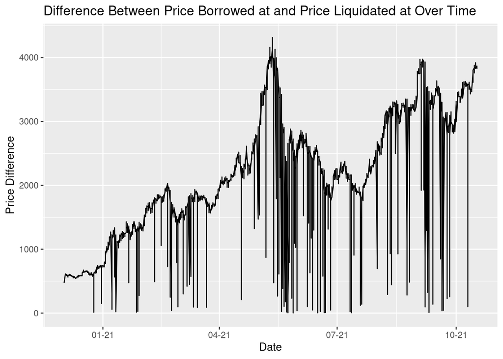

```r
ggplot(wethBorrowLiquids,aes(x=as.Date(date),y=priceDiff)) +
  geom_line() +
  ggtitle("Difference Between Price Borrowed at and Price Liquidated at Over Time") +
  scale_x_date(date_labels="%m-%y") +
  xlab("Date") +
  ylab("Price Difference")
```

```r
# Regular Survival Analysis

km <- with(wethBorrowLiquids,Surv(timeDiff,status))
head(km,25)
```

```
##  [1] 18912.42+ 18912.42+ 18912.42+ 18912.42+ 18912.42+ 18912.42+ 18912.42+
##  [8] 18912.42+ 18912.42+ 18912.42+ 18912.42+ 18912.42+ 18912.42+ 18912.42+
## [15] 18912.42+ 18912.42+ 18912.42+ 18912.42+ 18912.42+ 18912.42+ 18912.42+
## [22] 18912.42+ 18912.42+ 18912.42+ 18912.42+
```

```r
km_fit <- survfit(Surv(timeDiff,status) ~ 1, data=wethBorrowLiquids)
summary(km_fit, times = c(1,30,60,90*(1:10)))
```

```
## Call: survfit(formula = Surv(timeDiff, status) ~ 1, data = wethBorrowLiquids)
##
##  time n.risk n.event survival  std.err lower 95% CI upper 95% CI
##     1   8736       7    0.999 0.000302        0.999        1.000
##    30   8563     173    0.979 0.001519        0.976        0.982
##    60   8378     185    0.958 0.002139        0.954        0.962
##    90   8202     176    0.938 0.002577        0.933        0.943
##   180   7830     372    0.896 0.003271        0.889        0.902
##   270   7799      31    0.892 0.003319        0.886        0.899
##   360   7799       0    0.892 0.003319        0.886        0.899
##   450   7799       0    0.892 0.003319        0.886        0.899
##   540   7799       0    0.892 0.003319        0.886        0.899
##   630   7799       0    0.892 0.003319        0.886        0.899
##   720   7799       0    0.892 0.003319        0.886        0.899
##   810   7799       0    0.892 0.003319        0.886        0.899
##   900   7799       0    0.892 0.003319        0.886        0.899
```

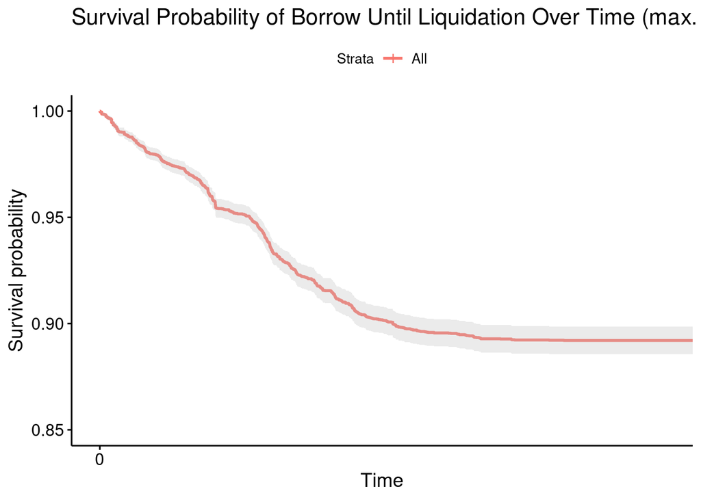

```r
ggsurvplot(km_fit, conf.int = TRUE, xlim = c(0,300), ylim = c(0.85,1)) +
  ggtitle("Survival Probability of Borrow Until Liquidation Over Time (max. 300 Days)")
```

```r
km2 <- with(wethBorrowLiquids,Surv(timeDiff,status))
head(km2,25)
```

```
##  [1] 18912.42+ 18912.42+ 18912.42+ 18912.42+ 18912.42+ 18912.42+ 18912.42+
##  [8] 18912.42+ 18912.42+ 18912.42+ 18912.42+ 18912.42+ 18912.42+ 18912.42+
## [15] 18912.42+ 18912.42+ 18912.42+ 18912.42+ 18912.42+ 18912.42+ 18912.42+
## [22] 18912.42+ 18912.42+ 18912.42+ 18912.42+
```

```r
km_fit_brm <- survfit(Surv(timeDiff,status) ~ borrowRateMode, data=wethBorrowLiquids)
summary(km_fit_brm, times = c(1,30,60,90*(1:10)))
```

```
## Call: survfit(formula = Surv(timeDiff, status) ~ borrowRateMode, data = wethBorrowLiquids)
##
##                 borrowRateMode=Stable
##  time n.risk n.event survival std.err lower 95% CI upper 95% CI
##     1    673       0    1.000 0.00000        1.000        1.000
##    30    665       8    0.988 0.00418        0.980        0.996
##    60    635      30    0.944 0.00890        0.926        0.961
##    90    611      24    0.908 0.01115        0.886        0.930
##   180    586      25    0.871 0.01293        0.846        0.896
##   270    586       0    0.871 0.01293        0.846        0.896
##   360    586       0    0.871 0.01293        0.846        0.896
##   450    586       0    0.871 0.01293        0.846        0.896
##   540    586       0    0.871 0.01293        0.846        0.896
##   630    586       0    0.871 0.01293        0.846        0.896
##   720    586       0    0.871 0.01293        0.846        0.896
```

[output cut: 18 more lines]

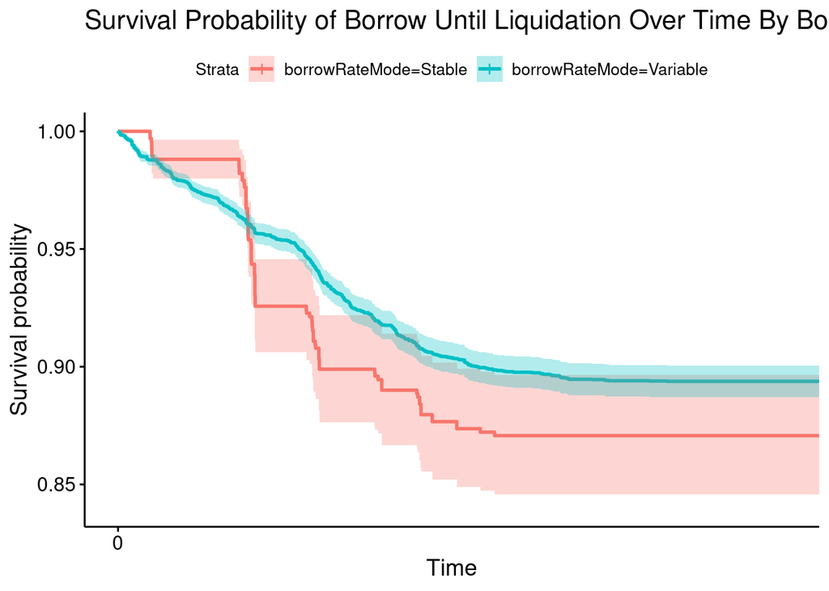

```r
ggsurvplot(km_fit_brm, conf.int = TRUE, xlim = c(0,300), ylim = c(0.84,1)) +
  ggtitle("Survival Probability of Borrow Until Liquidation Over Time By Borrow Rate Mode (max. 300 Days)")
```

```r
km3 <- with(wethBorrowLiquids,Surv(timeDiff,status))
head(km3,25)
```

```
##  [1] 18912.42+ 18912.42+ 18912.42+ 18912.42+ 18912.42+ 18912.42+ 18912.42+
##  [8] 18912.42+ 18912.42+ 18912.42+ 18912.42+ 18912.42+ 18912.42+ 18912.42+
## [15] 18912.42+ 18912.42+ 18912.42+ 18912.42+ 18912.42+ 18912.42+ 18912.42+
## [22] 18912.42+ 18912.42+ 18912.42+ 18912.42+
```

```r
km_fit_cr <- survfit(Surv(timeDiff,status) ~ principalReserve, data=wethBorrowLiquids)
summary(km_fit_cr, times = c(1,30,60,90*(1:10)))
```

```
## Call: survfit(formula = Surv(timeDiff, status) ~ principalReserve,
##     data = wethBorrowLiquids)
##
## 7799 observations deleted due to missingness
##                 principalReserve=BUSD
##  time n.risk n.event survival std.err lower 95% CI upper 95% CI
##     1      7       0    1.000   0.000        1.000            1
##    30      5       2    0.714   0.171        0.447            1
##    60      4       1    0.571   0.187        0.301            1
##    90      4       0    0.571   0.187        0.301            1
##
##                 principalReserve=CRV
##         time       n.risk      n.event     survival      std.err lower 95% CI
##            1            2            0            1            0            1
## upper 95% CI
##            1
##
##                 principalReserve=DAI
##  time n.risk n.event survival std.err lower 95% CI upper 95% CI
##     1    130       0   1.0000  0.0000      1.00000       1.0000
##    30    113      17   0.8692  0.0296      0.81316       0.9292
##    60     95      18   0.7308  0.0389      0.65836       0.8111
##    90     69      26   0.5308  0.0438      0.45156       0.6239
##   180      3      66   0.0231  0.0132      0.00754       0.0706
##
##                 principalReserve=GUSD
##  time n.risk n.event survival std.err lower 95% CI upper 95% CI
##     1     12       0     1.00   0.000       1.0000        1.000
##    30     12       0     1.00   0.000       1.0000        1.000
##    60     12       0     1.00   0.000       1.0000        1.000
##    90     12       0     1.00   0.000       1.0000        1.000
##   180      3       9     0.25   0.125       0.0938        0.666
##
##                 principalReserve=MANA
##  time n.risk n.event survival std.err lower 95% CI upper 95% CI
##     1      6       0        1       0            1            1
##    30      6       0        1       0            1            1
##    60      6       0        1       0            1            1
##    90      6       0        1       0            1            1
##
```

[output cut: 47 more lines]

```
##
##                 principalReserve=WETH
##  time n.risk n.event survival std.err lower 95% CI upper 95% CI
##     1     39       7   0.8478  0.0530       0.7501        0.958
##    30     32       7   0.6957  0.0678       0.5746        0.842
##    60     23       9   0.5000  0.0737       0.3745        0.668
##    90     18       5   0.3913  0.0720       0.2729        0.561
##   180      3      15   0.0652  0.0364       0.0218        0.195
##
##                 principalReserve=ZRX
##  time n.risk n.event survival std.err lower 95% CI upper 95% CI
##     1      6       0    1.000   0.000        1.000            1
##    30      4       2    0.667   0.192        0.379            1
##    60      2       2    0.333   0.192        0.108            1
##    90      2       0    0.333   0.192        0.108            1
```

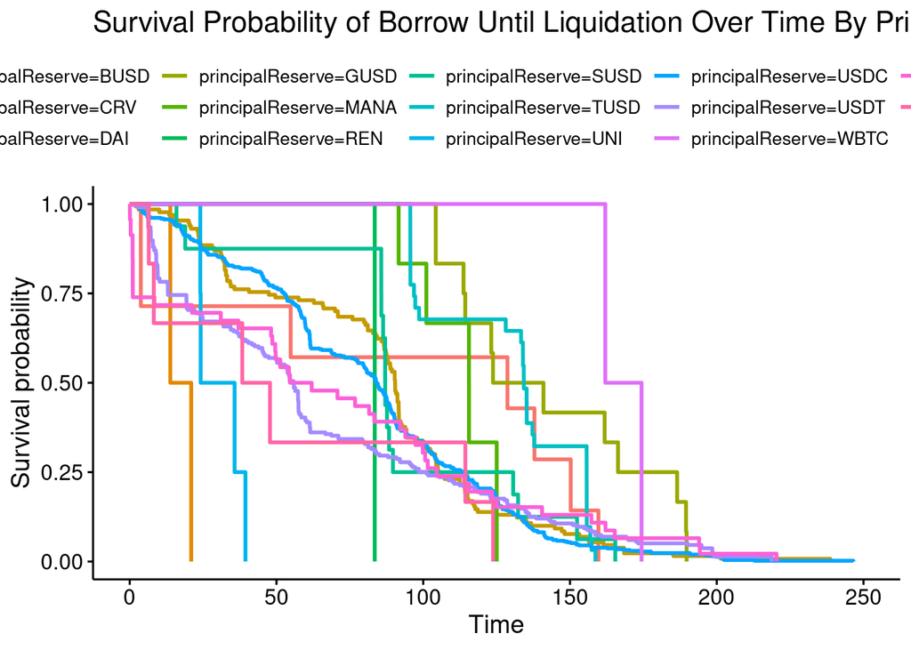

```r
ggsurvplot(km_fit_cr) +
  ggtitle("Survival Probability of Borrow Until Liquidation Over Time By Principal Reserve of Loan")
```

```r
cox <- coxph(Surv(timeDiff,status) ~ borrowRateMode + principalReserve,
             data=wethBorrowLiquids)
summary(cox)
```

```
## Call:
## coxph(formula = Surv(timeDiff, status) ~ borrowRateMode + principalReserve,
##     data = wethBorrowLiquids)
##
##   n= 944, number of events= 944
##    (7799 observations deleted due to missingness)
##
##                             coef exp(coef) se(coef)      z Pr(>|z|)
## borrowRateModeStable     0.12252   1.13035  0.11459  1.069  0.28498
## borrowRateModeVariable        NA        NA  0.00000     NA       NA
## principalReserveAmmDAI        NA        NA  0.00000     NA       NA
## principalReserveAmmUSDC       NA        NA  0.00000     NA       NA
## principalReserveAmmUSDT       NA        NA  0.00000     NA       NA
## principalReserveAmmWETH       NA        NA  0.00000     NA       NA
## principalReserveAMPL          NA        NA  0.00000     NA       NA
## principalReserveBAL           NA        NA  0.00000     NA       NA
## principalReserveBAT           NA        NA  0.00000     NA       NA
## principalReserveBUSD    -0.83146   0.43541  0.55720 -1.492  0.13564
## principalReserveCRV      1.56243   4.77041  0.82033  1.905  0.05683 .
## principalReserveDAI     -0.52255   0.59301  0.41803 -1.250  0.21129
## principalReserveENJ           NA        NA  0.00000     NA       NA
## principalReserveFRAX          NA        NA  0.00000     NA       NA
## principalReserveGUSD    -1.32031   0.26705  0.50109 -2.635  0.00842 **
## principalReserveLINK          NA        NA  0.00000     NA       NA
## principalReserveMANA    -0.81452   0.44285  0.57749 -1.410  0.15841
## principalReservePAX           NA        NA  0.00000     NA       NA
## principalReserveREN     -0.08889   0.91495  1.08077 -0.082  0.93445
## principalReserveSNX           NA        NA  0.00000     NA       NA
## principalReserveSUSD    -0.56427   0.56877  0.47924 -1.177  0.23902
## principalReserveTUSD    -1.14338   0.31874  0.44686 -2.559  0.01051 *
## principalReserveUNI      1.04571   2.84542  0.64815  1.613  0.10666
## principalReserveUSDC    -0.47864   0.61962  0.41148 -1.163  0.24474
## principalReserveUSDT    -0.35018   0.70456  0.41490 -0.844  0.39867
## principalReserveWBTC    -1.66130   0.18989  0.81790 -2.031  0.04224 *
## principalReserveWETH    -0.45648   0.63351  0.43499 -1.049  0.29399
## principalReserveXSUSHI        NA        NA  0.00000     NA       NA
## principalReserveYFI           NA        NA  0.00000     NA       NA
## principalReserveZRX           NA        NA  0.00000     NA       NA
## ---
## Signif. codes:  0 '***' 0.001 '**' 0.01 '*' 0.05 '.' 0.1 ' ' 1
```

[output cut: 22 more lines]

```
## principalReserveSUSD       0.5688     1.7582   0.22234    1.4550
## principalReserveTUSD       0.3187     3.1374   0.13276    0.7653
## principalReserveUNI        2.8454     0.3514   0.79880   10.1358
## principalReserveUSDC       0.6196     1.6139   0.27661    1.3880
## principalReserveUSDT       0.7046     1.4193   0.31243    1.5889
## principalReserveWBTC       0.1899     5.2662   0.03822    0.9434
## principalReserveWETH       0.6335     1.5785   0.27008    1.4860
## principalReserveXSUSHI         NA         NA        NA        NA
## principalReserveYFI            NA         NA        NA        NA
## principalReserveZRX            NA         NA        NA        NA
##
## Concordance= 0.589  (se = 0.011 )
## Likelihood ratio test= 51.04  on 14 df,   p=4e-06
## Wald test            = 50.34  on 14 df,   p=5e-06
## Score (logrank) test = 57.17  on 14 df,   p=4e-07
```

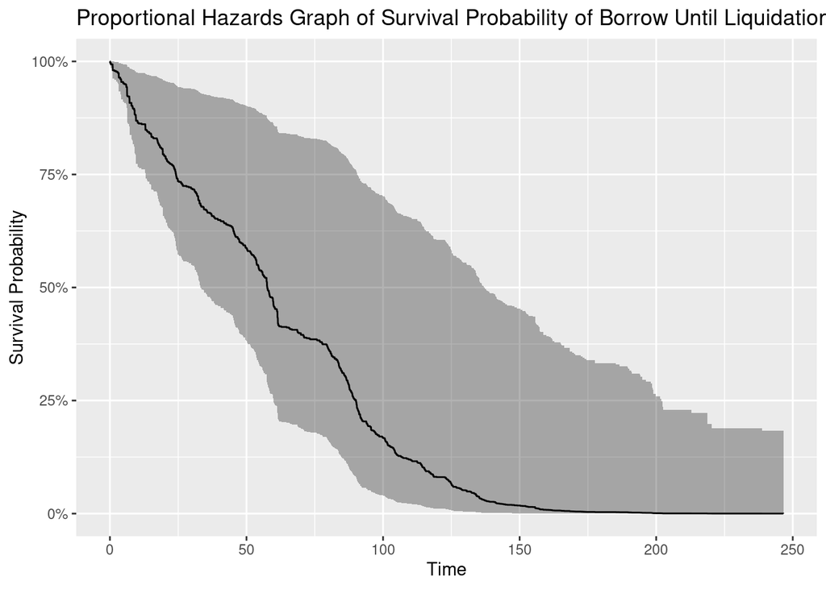

```r
cox_fit <- survfit(cox)
autoplot(cox_fit) +
  ggtitle("Proportional Hazards Graph of Survival Probability of Borrow Until Liquidation Over Time By Borrow Rate Mode, Principal Reserve of Loan") +
  xlab("Time") +
  ylab("Survival Probability")
```